# Simple Linear Regression

## Intervals for \(\hat{y}^*\) and \(Y^*\)

## A note on notation

- Capital letters are random variables (e.g. \(X\) and \(Y\)) while lower case letters are the values that those variables have taken.
- If the \(x\) or the \(y\) has a subscript, it's referring to that coordinate of one of the observations. e.g. \(x_i\), \(x_n\).
- If it has a hat, that means it's an estimate. e.g. \(\hat{y}_i\), \(\hat{\beta}_1\).
- If it has an asterisk, that means it's a new specific value that's not in the data set. e.g. \(x^*\).
- What does \(\hat{y}^*\) mean?
- What does \(Y^*\) mean?

## Considering a single data set

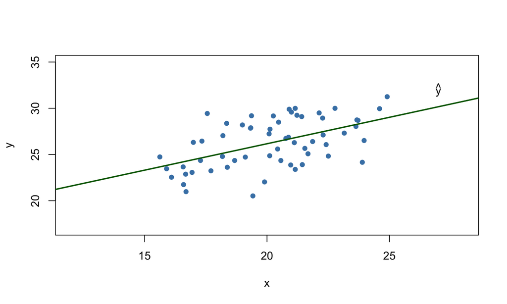

## Interval for \(\hat{y}^*\)

What value would we predict for a new \(x^*\)?

\[ \hat{y}^* = \hat{\beta}_0 + \hat{\beta}_1 * x^* \]

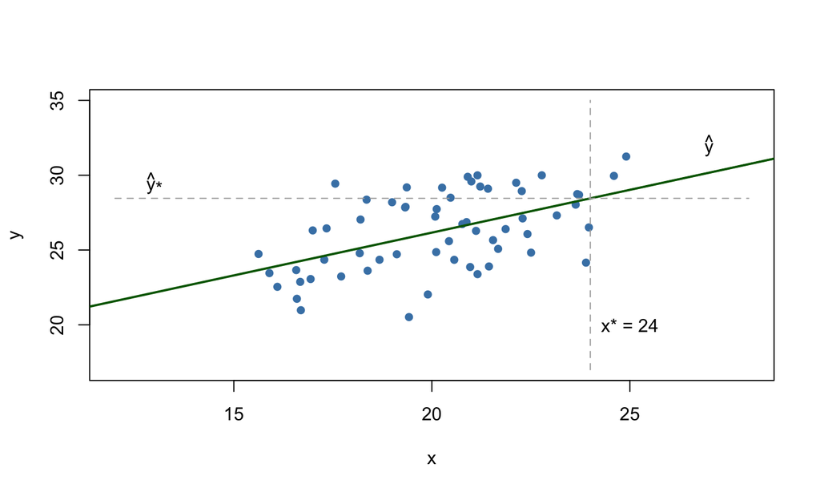

## Interval for \(\hat{y}^*\)

How much uncertainty do we have in that prediction?

\[ \hat{y}^* = \hat{\beta}_0 + \hat{\beta}_1 * x^* \]

Two sources of uncertainty:

1. estimating \(\beta_0\)
2. estimating \(\beta_1\)

We can calculate \(SE(\hat{y}^*)\):

\[ S \sqrt{\frac{1}{n} + \frac{(x^* - \bar{x})^2}{SXX}} \]

## Interval for \(\hat{y}^*\)

We know that \(\hat{y}^*\) will also be t-distributed, so we can form a CI:

\[ \hat{y}^* \pm t * SE(\hat{y}^*) \]

```r
m1 <- lm(f_data~x)
x_star <- 24
m1$coef[1] + m1$coef[2] * x_star
```

```
## (Intercept)
##       28.46
```

```r
predict(m1, data.frame(x = x_star), interval = "confidence")
```

```
##     fit   lwr   upr
## 1 28.46 27.35 29.56
```

## Interval for \(\hat{y}^*\)

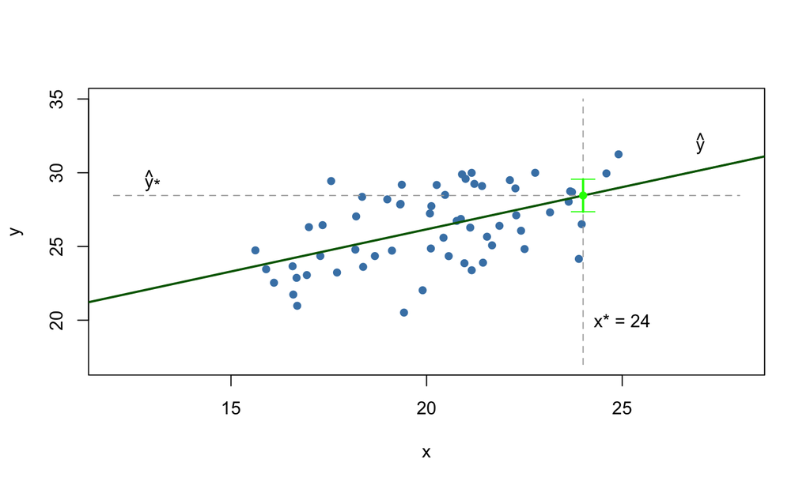

Consider the SE term:

\[ SE(\hat{y}^*) = S \sqrt{\frac{1}{n} + \frac{(x^* - \bar{x})^2}{SXX}} \]

For what values of \(x^*\) would you expect the interval for \(\hat{y}^*\) to be the narrowest?

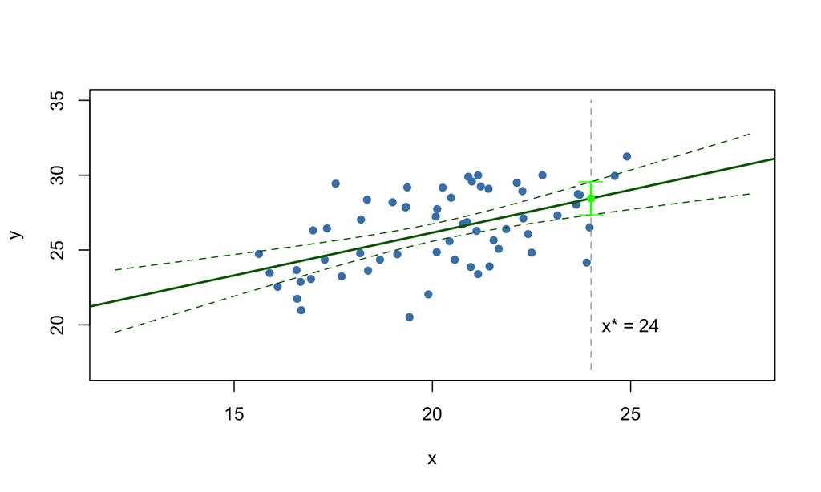

Look familiar?

## Prediction interval for \(Y^*\)

\(Y^*\) represents the *actual values* that you might be observed in the y. This comes not from the estimated mean function:

\[ \hat{y} = \hat{\beta}_0 + \hat{\beta}_1 * x \]

But from the estimated data generating function:

\[ Y = \hat{\beta}_0 + \hat{\beta}_1 * x + e\]

Which has *three* sources of uncertainty:

1. estimating \(\beta_0\).
2. estimating \(\beta_1\).
3. the random error \(e\).

## Prediction interval for \(Y^*\)

The SE for the CI:

\[ SE(\hat{y}^*) = S \sqrt{\frac{1}{n} + \frac{(x^* - \bar{x})^2}{SXX}} \]

gains an extra term for the PI:

\[ SE(Y^*) = S \sqrt{1 + \frac{1}{n} + \frac{(x^* - \bar{x})^2}{SXX}} \]

## Prediction interval for \(Y^*\)

What is the 95% prediction interval for \(x^* = 24\)?

\[ \hat{y}^* \pm t * SE(Y^*) \]

```r
m1 <- lm(f_data~x)
x_star <- 24
m1$coef[1] + m1$coef[2] * x_star
```

```
## (Intercept)
##       28.46
```

```r
predict(m1, data.frame(x = x_star), interval = "prediction")
```

```
##     fit   lwr  upr
## 1 28.46 23.81 33.1
```

## Prediction interval for \(Y^*\)

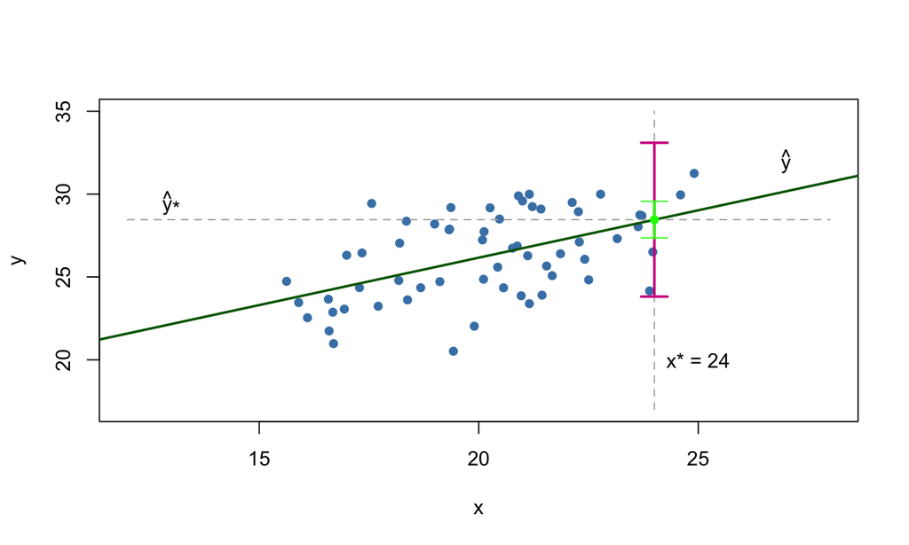

## Comparing intervals

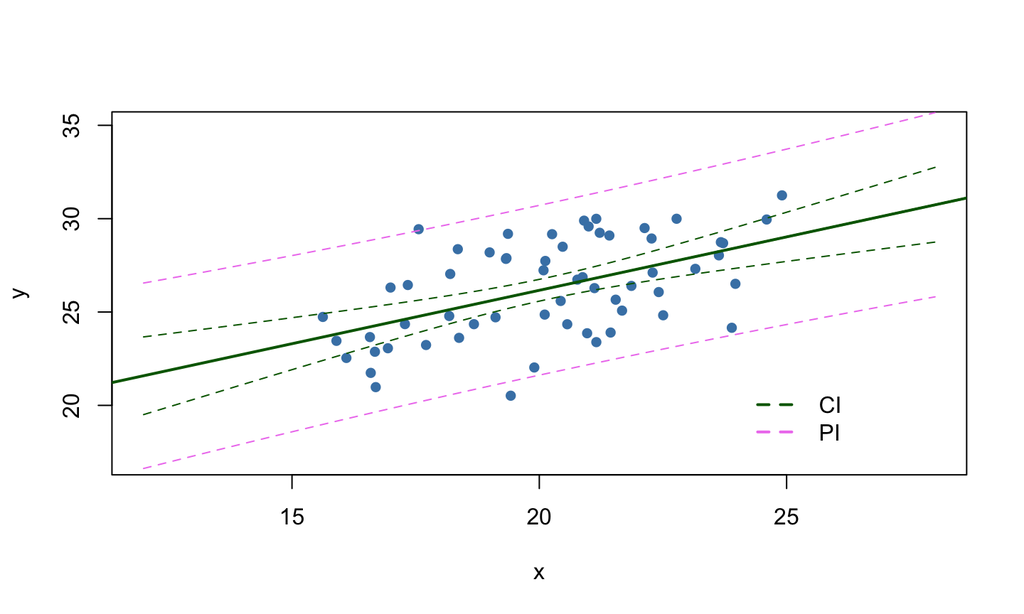

## Boardwork to revisit representing data with smooth functions

## Regression Assumptions

1. \(Y\) is related to \(x\) by a simple linear regression model. \[ E(Y|X) = \beta_0 + \beta_1 * x \]
2. The errors \(e_1, e_2, \ldots, e_n\) are independent of one another.
3. The errors have a common variance \(\sigma^2\).
4. The errors are normally distributed: \(e \sim N(0, \sigma^2)\)

Said another way…

\[ f(Y|X = x) \sim N(\beta_0 + \beta_1 * x, \sigma^2) \]

Regression is a *functional* smooth summary of the structure of the *conditional distribution* of \(Y|X\).

## Simulating from the conditional density function

```r
n <- 60
beta_0 <- 12
beta_1 <- .7
sigma <- 2
x <- rnorm(n, mean = 20, sd = 3)
f_mean <- beta_0 + beta_1 * x # mean function
f_data <- f_mean + rnorm(n, mean = 0, sd = sigma) # data generating function
```